```python
# Librerías necesarias para el estudio
import pandas as pd
import networkx as nx
import numpy as np
import os.path
import matplotlib.pyplot as plt
import math
import seaborn as sns
import random
from statsmodels.stats.multitest import multipletests
from scipy.stats import ttest_ind, mannwhitneyu, shapiro, chi2_contingency, ranksums, wilcoxon
from tabulate import tabulate
from itertools import combinations
from sklearn import metrics, svm, linear_model
from sklearn.model_selection import train_test_split
from neuroCombat import neuroCombat
from sklearn.preprocessing import StandardScaler, MinMaxScaler
from collections import Counter
from combat.pycombat import pycombat
from sklearn.decomposition import PCA
from sklearn.model_selection import cross_val_score, KFold
```

# 1. Importación de datos

En esta sección, procedemos a importar los diferentes ficheros que son necesarios para el presente estudio. Estos son:

- *mindboggle_ROIs.txt* - Nombre de las diferentes regiones del cerebro y su correspondiente orden de aparición en las matrices de conectividad
- *clinic.csv* - Datos clínicos de los sujetos que participan en el estudio
- *XXXX_FA_factor.csv* - Matriz de conectividad estructural del sujeto XXX
- *XXXX_GM_matrix.csv* - Matriz de conectividad morfológica del sujeto XXXX
- *XXXX_r_matrix.csv* - Matriz de conectividad funcional del sujeto XXXX

```python
# Listado de regiones cerebrales (en su respectivo orden de aparición en las matrices de conectividad)
nodes = pd.read_csv('Datasets/mindboggle_ROIs.txt', sep='\t')["[ sROI_MINDBOGGLE]"].to_list()
num_nodes = len(nodes)
edges = [tuple(sorted(c, key=str.casefold)) for c in combinations(nodes,2) if c[0]!=[1]]

# Listado de variables que tendremos en cuenta (posiciones [i,j] de la diagonal superior de las matrices)
variables = []
for i in range(0,num_nodes):
    for j in range(i+1,num_nodes):
        variables.append((i,j))

# Datos clínicos de los sujetos
clinic = pd.read_csv('Datasets/clinic.csv')

# Modificamos el datatype de la variable 'sex' para que sea categórica
clinic['sex'] = clinic['sex'].astype('category')

# Listado de identificadores de cada uno de los grupos (pacientes/controles)
patients = dict.fromkeys(clinic[clinic.controls_ms==1]['id'].to_list())
controls = dict.fromkeys(clinic[clinic.controls_ms==0]['id'].to_list())

# Matrices de conectividad de cada uno de los sujetos
def import_connectivity_matrix(subjects):
    '''
    Dada una lista de IDs, esta función retorna
    las matrices FA, GM y rfMRI para cada uno de ellos
    en formato diccionario {ID : {FA: [], GM: [], rfMRI: []}}
    '''
    for s in subjects:
        subjects[s]               = dict.fromkeys(['FA','GM','rfMRI'])
        subjects[s]['FA']         = pd.read_csv('Datasets/subject_networks_FA_v1/'       + s +'_FA_factor.csv', header=None)
        subjects[s]['GM']         = pd.read_csv('Datasets/subject_networks_GM_v1-no-thr/'+ s +'_GM_matrix.csv', header=None)
        subjects[s]['rfMRI']      = pd.read_csv('Datasets/subject_networks_rfMRI_v1/'    + s +'_r_matrix.csv' , header=None)
        subjects[s]['zAttention'] = list(clinic[clinic.id == s]['zattention'])[0]


import_connectivity_matrix(patients)
import_connectivity_matrix(controls)
```

```python
print("Número de sujetos: {}".format(len(patients)+len(controls)))
print("Número de regiones cerebrales: {}".format(len(nodes)))
print("Número de conexiones cerebrales: {}".format(len(edges)))
```

```
Número de sujetos: 165
Número de regiones cerebrales: 76
Número de conexiones cerebrales: 2850
```

# 2. Preprocesamiento de datos

Dadas *m* matrices de conectividad (estructural, morfológica o funcional) de tamaño *nxn*, en este estudio – dada la naturaleza simétrica de estas matrices – únicamente consideraremos los valores de la diagonal superior de cada una de ellas. Esto resulta en un total de n(n-1)/2 variables de longitud *m*.

Para cada variable *y*, con el fin de minimizar los factores de confusión, llevaremos a cabo los ajustes descritos en los siguientes apartados.

```python
# -----------------------------------
# Analizamos los efectos del scanner
# -----------------------------------

def plot_general():
    for t in ['FA']:

        all_values_MSVIS = {}
        all_values_FIS = {}

        for (i,j) in variables:

            all_values_MSVIS[(i,j)] = []
            all_values_FIS[(i,j)] = []

        for group in [controls,patients]:
            for s in group:
                for (i,j) in variables:
                    if 'MSVIS' in s:
                        all_values_MSVIS[(i,j)].append(group[s][t][i][j])
                    else:
                        all_values_FIS[(i,j)].append(group[s][t][i][j])

    x = pd.DataFrame(all_values_MSVIS)

    x_scaled = StandardScaler().fit_transform(x)
    pca = PCA(n_components=2)
    pca_features = pca.fit_transform(x_scaled)
    pca_MSVIS = pd.DataFrame(
        data=pca_features,
        columns=['PC1','PC2'])
    pca_MSVIS['color']='red'



    x = pd.DataFrame(all_values_FIS)

    x_scaled = StandardScaler().fit_transform(x)
    pca = PCA(n_components=2)
    pca_features = pca.fit_transform(x_scaled)
    pca_FIS = pd.DataFrame(
        data=pca_features,
        columns=['PC1','PC2'])
    pca_FIS['color']='blue'

    data = pd.concat([pca_FIS,pca_MSVIS])
    plt.scatter(data['PC1'],data['PC2'], c=data['color'])
    plt.axis([-50, 60, -50, 40])

def scatter_weights():
    x = []
    y = []
    color=[]

    for t in ['FA']:
        for group in [controls,patients]:
            for s in group:
                x.append(group[s][t][56][68])
                y.append(group[s][t][59][64])
                if 'MSVIS' in s:
                    color.append('red')
                else:
                    color.append('blue')

    plt.scatter(x,y, c=color)
```

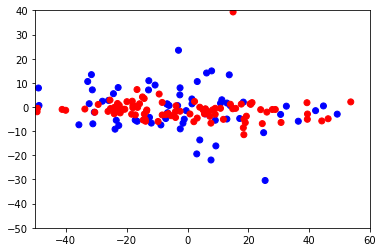

```python
plot_general()
```

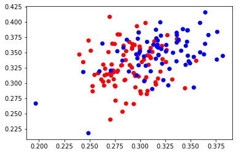

```python
scatter_weights()
```

```python
# ------------------------------------------------------------------------------------------------------------
#  Imputación de valores nulos (para la harmonización de las matrices FA) -> reemplazamos los 0 por la media
# ------------------------------------------------------------------------------------------------------------

for t in ['FA']:

    all_values = []

    for group in [controls,patients]:
        for s in group:
            for (i,j) in variables:
                all_values.append(group[s][t][i][j])

    all_values_mean = np.mean(all_values)


# Reemplazamos los valores ceros por la media de los valores (guardando los enlaces para después)
cambiar_valores = []
for t in ['FA']:
    for group in [controls,patients]:
        for s in group:
            for (i,j) in variables:
                  if(group[s][t][i][j]==0):
                        group[s][t][i][j] = all_values_mean
                        cambiar_valores.append((t,group,s,i,j))
```

```python
# --------------------------------------------------------------------------
#  Harmonización de pesos
# --------------------------------------------------------------------------

# Preparación del campo data
for t in ['FA']:

    batch = []
    subject_type = []
    real_values = []
    subjects = []
    indexes = []

    for group in [controls,patients]:
            for s in group:
                subjects.append(s)
                batch.append(1 if 'MSVIS' in s else 2)
                subject_type.append(1 if group==patients else 2)

    for (i,j) in variables:
        real_values_ij = []
        indexes.append((i,j))
        for group in [controls,patients]:
            for s in group:
                real_values_ij.append(group[s][t][i][j])

        real_values.append(real_values_ij)

data = pd.DataFrame(real_values)
data.columns = subjects
data.index = indexes

# Harmonización
covars = {}
covars = {'batch':batch,
          'subject_type':subject_type}
covars = pd.DataFrame(covars)

# To specify names of the variables that are categorical:
categorical_cols = ['subject_type']

# To specify the name of the variable that encodes for the scanner/batch covariate:
batch_col = 'batch'

#Harmonization step:
data_combat = neuroCombat(dat=data,
    covars=covars,
    batch_col=batch_col,
    categorical_cols=categorical_cols)

data = pd.DataFrame(data_combat["data"])
data.columns = subjects
data.index = indexes
data

# Reemplazamos los valores existentes
for s in data.columns:
    for (i,j) in data.index:
        if s in patients:
            patients[s]['FA'][i][j] = data[s][(i,j)]
        if s in controls:
            controls[s]['FA'][i][j] = data[s][(i,j)]
```

```
[neuroCombat] Creating design matrix
[neuroCombat] Standardizing data across features
[neuroCombat] Fitting L/S model and finding priors
[neuroCombat] Finding parametric adjustments
[neuroCombat] Final adjustment of data
```

```python
# --------------------------------------------------------------------------
# Reestablecemos los valores nulos a cero
# --------------------------------------------------------------------------
for (t,group,s,i,j) in cambiar_valores:
    group[s][t][i][j]=0
```

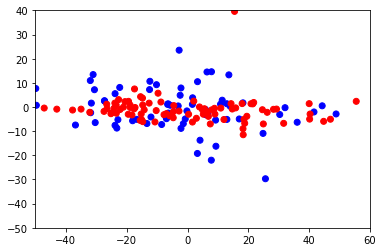

```python
plot_general()
```

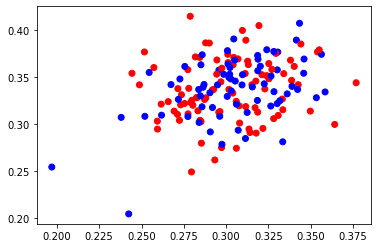

```python
scatter_weights()
```

```python
# --------------------------------------------------------------------------
# Corrección por edad y sexo
# --------------------------------------------------------------------------

control_means = dict.fromkeys(['FA','GM','rfMRI'])

for t in ['FA','GM','rfMRI']:
    control_means[t] = {}

    for (i,j) in variables:

        # Calculamos, para cada variable [i,j], la media de los valores de los sujetos control (solo diagonal superior)
        control_means[t][(i,j)] = np.mean([controls[s][t][i][j] for s in controls])

        # De cada sujeto, recuperamos el sexo, la edad y el valor real de la variable
        subjects = []
        age = []
        gender = []
        real_values = []

        for group in [controls,patients]:
            for s in group:
                subjects.append(s)
                age.append(list(clinic[clinic.id==s]['age'])[0])
                gender.append(list(clinic[clinic.id==s]['sex'])[0])
                real_values.append(group[s][t][i][j])

        # Ajustamos los valores a una regresión lineal en función de la edad y el sexo
        x = [age,gender]; x = np.array(x).T
        y = real_values; y = np.array(y)
        new_values = linear_model.LinearRegression().fit(x,y).predict(x)

        # Reemplazamos el valor actual por el nuevo valor
        for group in [controls,patients]:
            for s in group:
                    k = subjects.index(s)
                    group[s][t][i][j]=real_values[k]-new_values[k]+control_means[t][(i,j)]
```

```python
# --------------------------------------------------------------------------
# Normalización de datos
# --------------------------------------------------------------------------

scaler = MinMaxScaler(feature_range=(0, 1))

# Normalizamos cada una de las variables
for t in ['FA','GM','rfMRI']:
    for (i,j) in variables:

        # De cada sujeto, recuperamos el valor real de la variable
        subjects = []
        real_values = []

        for group in [controls,patients]:
            for s in group:
                subjects.append(s)
                real_values.append(group[s][t][i][j])

        # Normalizamos
        new_values = scaler.fit_transform(np.array(real_values).reshape(-1, 1))

        # Reemplazamos el valor actual por el nuevo valor
        for group in [controls,patients]:
            for s in group:
                k = subjects.index(s)
                group[s][t][i][j]=new_values[k]
```

```python
# --------------------------------------------------------------------------
# Filtrado de conexiones que aparezcan en más del 60% de los sujetos sanos (solo FA)
# --------------------------------------------------------------------------

counter = {}

# Calculamos, para cada variable, el número de sujetos controles en las que se encuentra presente
for (i,j) in variables:
    counter[(i,j)] =0
    for s in controls:
        if controls[s]['FA'][i][j]!=0:
            counter[(i,j)] = counter[(i,j)] + 1

# conexiones que aparecen en más del 60% de los controles
conexiones = [c for c in counter if counter[c]/len(controls)>=0.6]
print(len(conexiones))

# Eliminamos aquellas que no se encuentran en el listado anterior
for group in [patients, controls]:
    for s in group:
            for (i,j) in variables:
                if (i,j) not in conexiones:
                    group[s]['FA'][i][j] = 0
```

```
2690
```

```python
# --------------------------------------------------------------------------
# eliminar conectividades <0.1 (las ponemos a cero)
# --------------------------------------------------------------------------
for group in [patients, controls]:
    for s in group:
        for matrix in ['FA','GM','rfMRI']:
            for (i,j) in variables:
                if group[s][matrix][i][j] < 0.1: #or np.isnan(group[s][matrix][i][j]) == True:
                    group[s][matrix][i][j] = 0
```

# 3. Estudio de los datos clínicos y demográficos

En este apartado llevamos a cabo un pequeño estudio de los datos demográficos de los sujetos y verificamos si existen diferencias significativas entre los dos grupos (pacientes/controles) para las variables comunes.

```python
def mean_std(col,new_label,only_ms=0):
    '''
    Function that returns an array with four elements:
        - new_label
        - mean+std for patients
        - mean+std for controls (only if only_ms=0)
        - Student t-test p-value (only if only_ms=0)
    '''
    variable = [new_label]
    col_patients = clinic[clinic.controls_ms == 1][col]

    # [mean, std] for MS patients
    variable.append(col_patients.agg(['mean','std']).round(2).to_list())

    if only_ms == 0:

        # [mean, std] for controls
        col_controls = clinic[clinic.controls_ms == 0][col]
        variable.append(col_controls.agg(['mean','std']).round(2).to_list())

        # Student t-test
        variable.append(mannwhitneyu(col_patients.to_list(),
                                  col_controls.to_list())
                        .pvalue)
    else:
        variable.append("n/a")
        variable.append("n/a")

    return variable


def count_pct(col,new_label):
    variable = [new_label]

    col_patients = list(clinic[clinic.controls_ms == 1][col])
    col_controls = list(clinic[clinic.controls_ms == 0][col])

    # [mean, std] for MS patients
    counts = Counter(col_patients)
    variable.append([counts[0],round(counts[0]/(counts[0]+counts[1])*100,2)])

    # [mean, std] for MS controls
    counts = Counter(col_controls)
    variable.append([counts[0],round(counts[0]/(counts[0]+counts[1])*100,2)])

    # test
    pvalue = chi2_contingency([list(Counter(col_patients).values()),
                               list(Counter(col_controls).values())])[1]
    variable.append(pvalue)

    return variable

data = []
data.append(['Count', len(patients), len(controls), 'n/a'])
data.append(mean_std('age','Age'))
data.append(count_pct('sex','Sex (F, %)'))
data.append(mean_std('dd','Disease duration',only_ms=1))
data.append(mean_std('zpasat','zPASAT score',only_ms=1))
data.append(mean_std('sdmtz','zSDMT score',only_ms=1))
data.append(mean_std('zattention','zAttention score',only_ms=1))


print (tabulate(data, headers=["Variable", "MS Patients", "Controls", "p-valor"]))
```

```
Variable          MS Patients     Controls      p-valor
----------------  --------------  ------------  ----------------------
Count             147             18            n/a
Age               [47.33, 10.15]  [36.62, 9.6]  0.00017663447852410628
Sex (F, %)        [104, 70.75]    [15, 83.33]   0.39784392998317575
Disease duration  [15.96, 9.05]   n/a           n/a
zPASAT score      [-0.29, 1.33]   n/a           n/a
zSDMT score       [0.08, 1.06]    n/a           n/a
zAttention score  [-0.29, 1.04]   n/a           n/a
```

[figure not shown]

```python
plt.boxplot([clinic[clinic.controls_ms == 0]['age'],clinic[clinic.controls_ms == 1]['age']])
plt.xticks([1,2],['MS patients','Controls'])
plt.title('Age')

# statistical annotation
x1, x2 = 1, 2  # columns 'Sat' and 'Sun' (first column: 0, see plt.xticks())
y, h, col = 75 + 2, 2, 'k'

plt.plot([x1, x1, x2, x2], [y, y+h, y+h, y], lw=1.5, c=col)
plt.text((x1+x2)*.5, y-h, "***", ha='center', va='bottom', color=col)

plt.show()
plt.show()
```

Observamos que los grupos presentan diferencias significativas en lo que respecta a la edad.

# 4. Cálculo de métricas de grafos

## 4.1. Transformación a grafos

En esta sección, se transforman las diferentes matrices de conectividad en objetos de tipo grafo donde

- cada nodo se corresponde con una región cerebral
- se genera un enlace entre dos nodos si la correspondiente conectividad es diferente de 0
- el peso del enlace se corresponde con el valor de la conectividad

```python
def sym_matrix_to_graph (data, nodes):
    """
    Dada una matriz simetrica 'data' donde v[i,j] es el valor de la posición [i,j],
    se retorna un grafo con aristas [i,j], con nombre de los nodos nodes[i] y nodes[j],
    y peso de la arista v[i,j]
    """
    # Declaramos la lista donde se almacenarán los diferentes pares de aristas y pesos
    weighted_edges = []

    # Calculamos las aristas y sus correspondientes pesos
    for (i,j) in variables:
        # no consideramos aristas aquellas conectividades que son 0
        if data[i][j]!=0: # and pd.isna(data[i][j])==False:
            weighted_edges.append((nodes[i], nodes[j],data[i][j]))

    # Generamos el grafo correspondiente
    G = nx.Graph()
    G.add_weighted_edges_from(weighted_edges)

    # Retornamos el grafo
    return G


def connectivity_graphs(subjects, nodes):
    '''
    Dado un diccionario {ID : {FA: [], GM: [], rfMRI: []}}, donde los [] corresponden
    a datasets, esta función aplica sym_matrix_to_graph() function a cada dataset
    '''
    for s in subjects.keys():
        subjects[s]['FA']    = sym_matrix_to_graph(subjects[s]['FA'],nodes)
        subjects[s]['GM']    = sym_matrix_to_graph(subjects[s]['GM'],nodes)
        subjects[s]['rfMRI'] = sym_matrix_to_graph(subjects[s]['rfMRI'],nodes)

connectivity_graphs(patients,nodes)
connectivity_graphs(controls,nodes)
```

## 4.2. Métricas globales

En este apartado, se calcula para cada uno de los grafos (tanto estructurales, morfológicos, como funcionales) las siguientes métricas:

- strength - suma de los grados (ponderados por peso)
- transitivity - ratio de triangulos
- global efficiency - media de la inversa de los caminos más cortos entre pares de nodos
- assortativity - coeficiente de correlación entre los grados (ponderados por peso) de todos los nodos en dos extremos opuestos de un enlace
- path length - media de las longitudes de los caminos más cortos entre pares de nodos
- betweenness centrality - media de la fracción de todos los pares de caminos más cortos que pasan a través de un nodo

Una vez calculadas las métricas, se procede a comparar cada una de ellas entre los sujetos pacientes y los sujetos control, para ver si existen diferencias significativas entre ambos grupos. Para ello, empleamos el test U de Mann-Whitney con corrección de Bonferroni.

```python
def graph_global_metrics(graph_list, group):
    '''
    Dada una lista de grafos, esta función retorna, para cada uno de ellos las siguientes
    métricas: strength, transitivity, global efficiency, assortativity, clustering coefficient,
    betwenness centrality
    '''
    cmetrics = {}

    # Cálculo de métricas
    cmetrics['subjects']                         = group.keys()
    cmetrics['Strength']                         = [np.mean([w[1] for w in list(G.degree(weight='weight'))])
                                                   for G in graph_list]
    cmetrics['Transitivity']                     = [nx.transitivity(G) for G in graph_list]
    cmetrics['Global efficiency']                = [nx.global_efficiency(G,) for G in graph_list]
    cmetrics['Assortativity']                    = [nx.degree_pearson_correlation_coefficient(G,weight='weight')
                                                   for G in graph_list]
    cmetrics['Path length']                      = [nx.average_shortest_path_length(G) for G in graph_list]
    cmetrics['Betweenness centrality']           = [np.mean(list(nx.betweenness_centrality(G,weight='weight').values()))
                                                   for G in graph_list]



    # Retornamos los resultados
    return pd.DataFrame(cmetrics)



def global_metrics_summary(patients_metrics,controls_metrics, metrics, alternative='two-sided'):
    '''
    Retorna una tabla con el resumen de las métricas para ambos grupos de sujetos
    y el pvalor correspondiente
    '''
    data=[]

    for m in metrics:
        row = [m]

        patients_stats = (round(np.mean(patients_metrics[m]),2),
                          round(np.std (patients_metrics[m]),2))
        controls_stats = (round(np.mean(controls_metrics[m]),2),
                          round(np.std (controls_metrics[m]),2))
        pvalue = mannwhitneyu(patients_metrics[m], controls_metrics[m], alternative=alternative).pvalue

        row.append(patients_stats)
        row.append(controls_stats)
        row.append(pvalue)
        data.append(row)

    return data


def bonferroni_correction(data):
    '''
    Aplicación de corrección de Bonferroni
    '''
    pvals = [row[3] for row in data]
    adjusted_pvals = list(multipletests(pvals, alpha=0.05, method='bonferroni',is_sorted=False,returnsorted=False)[1])

    i = 0
    for row in data:
        row[3] = str(adjusted_pvals[i])+ ' (*)' if adjusted_pvals[i] <0.05 else adjusted_pvals[i]
        i=i+1

def plot_metric_boxplot(patients_metrics, controls_metrics, metric, pos):
    axs[pos[0], pos[1]].boxplot([patients_metrics[metric],controls_metrics[metric]])
    axs[pos[0], pos[1]].set_xticklabels(['MS patients','controls'])
    axs[pos[0], pos[1]].set_title(metric)


def drop_outliers(data_metrics, cmetrics):

    print("Old Shape: ", data_metrics.shape)

    # Calculate quantiles and IQR
    Q1 = data_metrics[cmetrics].quantile(0.25) # Same as np.percentile but maps (0,1) and not (0,100)
    Q3 = data_metrics[cmetrics].quantile(0.75)
    IQR = Q3 - Q1

    # Return a boolean array of the rows with (any) non-outlier column values
    condition = ~((data_metrics[cmetrics] <= (Q1 - 1.5 * IQR))
                  | (data_metrics[cmetrics] >= (Q3 + 1.5 * IQR))).any(axis=1)

    print("New Shape: ", data_metrics.shape)

    # Filter our dataframe based on condition
    return data_metrics[condition]
```

### 4.2.1. Conectividad estructural

```python
# Listados de matrices de conectividad estructural para cada uno de los grupos
patients_FA = [patients[s]['FA'] for s in patients.keys()]
controls_FA = [controls[s]['FA'] for s in controls.keys()]
```

```python
# Cálculo de métricas de grafos globales
patients_FA_metrics = graph_global_metrics(patients_FA, patients)
controls_FA_metrics = graph_global_metrics(controls_FA, controls)
cmetrics            = list(patients_FA_metrics.keys()[1:])
```

[figure not shown]

```python
fig, axs = plt.subplots(2, 3,figsize=(10, 6))
x1, x2 = 1, 2

plot_metric_boxplot(patients_FA_metrics,controls_FA_metrics,'Strength', [0,0])
y, h, col = 50, 2, 'k'
axs[0,0].plot([x1, x1, x2, x2], [y, y+h, y+h, y], lw=1.5, c=col)
axs[0,0].text((x1+x2)*.5, y-h, "*", ha='center', va='bottom', color=col)


plot_metric_boxplot(patients_FA_metrics,controls_FA_metrics,'Transitivity', [0,1])
y, h, col = 0.85, 0.01, 'k'
axs[0,1].plot([x1, x1, x2, x2], [y, y+h, y+h, y], lw=1.5, c=col)
axs[0,1].text((x1+x2)*.5, y-h, "ns", ha='center', va='bottom', color=col)

plot_metric_boxplot(patients_FA_metrics,controls_FA_metrics,'Global efficiency', [0,2])
y, h, col = 0.9, 0.008, 'k'
axs[0,2].plot([x1, x1, x2, x2], [y, y+h, y+h, y], lw=1.5, c=col)
axs[0,2].text((x1+x2)*.5, y-h, "ns", ha='center', va='bottom', color=col)

plot_metric_boxplot(patients_FA_metrics,controls_FA_metrics,'Assortativity', [1,0])
y, h, col = 0.10, 0.009, 'k'
axs[1,0].plot([x1, x1, x2, x2], [y, y+h, y+h, y], lw=1.5, c=col)
axs[1,0].text((x1+x2)*.5, y-h, "ns", ha='center', va='bottom', color=col)

plot_metric_boxplot(patients_FA_metrics,controls_FA_metrics,'Path length', [1,1])
y, h, col = 1.6, 0.015, 'k'
axs[1,1].plot([x1, x1, x2, x2], [y, y+h, y+h, y], lw=1.5, c=col)
axs[1,1].text((x1+x2)*.5, y-h, "ns", ha='center', va='bottom', color=col)

plot_metric_boxplot(patients_FA_metrics,controls_FA_metrics,'Betweenness centrality', [1,2])
y, h, col = 0.009, 0.00025, 'k'
axs[1,2].plot([x1, x1, x2, x2], [y, y+h, y+h, y], lw=1.5, c=col)
axs[1,2].text((x1+x2)*.5, y-h, "*", ha='center', va='bottom', color=col)


fig.subplots_adjust(left=0.08, right=0.98, bottom=0.05, top=0.9,
                    hspace=0.4, wspace=0.3)
```

```python
patients_FA_metrics = drop_outliers(patients_FA_metrics, cmetrics)
controls_FA_metrics = drop_outliers(controls_FA_metrics, cmetrics)
```

```
Old Shape:  (147, 7)
New Shape:  (147, 7)
Old Shape:  (18, 7)
New Shape:  (18, 7)
```

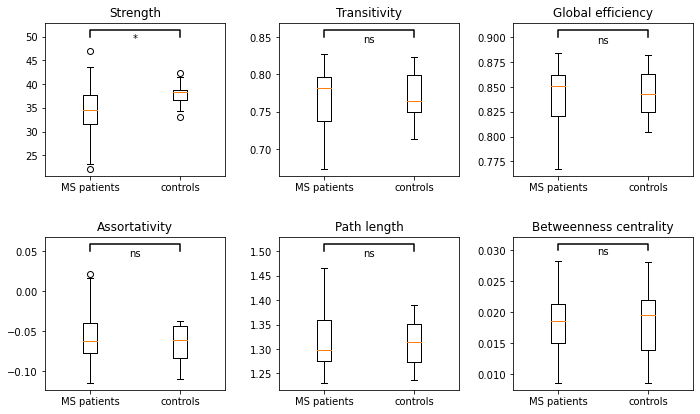

```python
fig, axs = plt.subplots(2, 3,figsize=(10, 6))

plot_metric_boxplot(patients_FA_metrics,controls_FA_metrics,'Strength', [0,0])
y, h, col = 50, 1.5, 'k'
axs[0,0].plot([x1, x1, x2, x2], [y, y+h, y+h, y], lw=1.5, c=col)
axs[0,0].text((x1+x2)*.5, y-h, "*", ha='center', va='bottom', color=col)


plot_metric_boxplot(patients_FA_metrics,controls_FA_metrics,'Transitivity', [0,1])
y, h, col = 0.85, 0.01, 'k'
axs[0,1].plot([x1, x1, x2, x2], [y, y+h, y+h, y], lw=1.5, c=col)
axs[0,1].text((x1+x2)*.5, y-h, "ns", ha='center', va='bottom', color=col)

plot_metric_boxplot(patients_FA_metrics,controls_FA_metrics,'Global efficiency', [0,2])
y, h, col = 0.9, 0.008, 'k'
axs[0,2].plot([x1, x1, x2, x2], [y, y+h, y+h, y], lw=1.5, c=col)
axs[0,2].text((x1+x2)*.5, y-h, "ns", ha='center', va='bottom', color=col)

plot_metric_boxplot(patients_FA_metrics,controls_FA_metrics,'Assortativity', [1,0])
y, h, col = 0.05, 0.009, 'k'
axs[1,0].plot([x1, x1, x2, x2], [y, y+h, y+h, y], lw=1.5, c=col)
axs[1,0].text((x1+x2)*.5, y-h, "ns", ha='center', va='bottom', color=col)

plot_metric_boxplot(patients_FA_metrics,controls_FA_metrics,'Path length', [1,1])
y, h, col = 1.5, 0.015, 'k'
axs[1,1].plot([x1, x1, x2, x2], [y, y+h, y+h, y], lw=1.5, c=col)
axs[1,1].text((x1+x2)*.5, y-h, "ns", ha='center', va='bottom', color=col)

plot_metric_boxplot(patients_FA_metrics,controls_FA_metrics,'Betweenness centrality', [1,2])
y, h, col = 0.030, 0.0010, 'k'
axs[1,2].plot([x1, x1, x2, x2], [y, y+h, y+h, y], lw=1.5, c=col)
axs[1,2].text((x1+x2)*.5, y-h, "ns", ha='center', va='bottom', color=col)


fig.subplots_adjust(left=0.08, right=0.98, bottom=0.05, top=0.9,
                    hspace=0.4, wspace=0.3)
```

```python
data = global_metrics_summary(patients_FA_metrics,controls_FA_metrics,cmetrics, alternative='less')
print(tabulate(data, headers=["Metric", "MS Patients", "Controls", "pvalue"]))
```

```
Metric                  MS Patients    Controls            pvalue
----------------------  -------------  -------------  -----------
Strength                (34.3, 4.52)   (37.99, 2.33)  0.000379175
Transitivity            (0.77, 0.03)   (0.77, 0.03)   0.346682
Global efficiency       (0.84, 0.02)   (0.84, 0.02)   0.41103
Assortativity           (-0.06, 0.03)  (-0.07, 0.02)  0.766465
Path length             (1.31, 0.05)   (1.31, 0.04)   0.591241
Betweenness centrality  (0.02, 0.0)    (0.02, 0.01)   0.5198
```

```python
bonferroni_correction(data)
print(tabulate(data, headers=["Metric", "MS Patients", "Controls", "pvalue"]))
```

```
Metric                  MS Patients    Controls       pvalue
----------------------  -------------  -------------  -------------------------
Strength                (34.3, 4.52)   (37.99, 2.33)  0.0022750472469307143 (*)
Transitivity            (0.77, 0.03)   (0.77, 0.03)   1.0
Global efficiency       (0.84, 0.02)   (0.84, 0.02)   1.0
Assortativity           (-0.06, 0.03)  (-0.07, 0.02)  1.0
Path length             (1.31, 0.05)   (1.31, 0.04)   1.0
Betweenness centrality  (0.02, 0.0)    (0.02, 0.01)   1.0
```

```python
data = global_metrics_summary(patients_FA_metrics,controls_FA_metrics,cmetrics, alternative='greater')
print(tabulate(data, headers=["Metric", "MS Patients", "Controls", "pvalue"]))
```

```
Metric                  MS Patients    Controls         pvalue
----------------------  -------------  -------------  --------
Strength                (34.3, 4.52)   (37.99, 2.33)  0.999629
Transitivity            (0.77, 0.03)   (0.77, 0.03)   0.655472
Global efficiency       (0.84, 0.02)   (0.84, 0.02)   0.591241
Assortativity           (-0.06, 0.03)  (-0.07, 0.02)  0.235328
Path length             (1.31, 0.05)   (1.31, 0.04)   0.411029
Betweenness centrality  (0.02, 0.0)    (0.02, 0.01)   0.482528
```

```python
bonferroni_correction(data)
print(tabulate(data, headers=["Metric", "MS Patients", "Controls", "pvalue"]))
```

```
Metric                  MS Patients    Controls         pvalue
----------------------  -------------  -------------  --------
Strength                (34.3, 4.52)   (37.99, 2.33)         1
Transitivity            (0.77, 0.03)   (0.77, 0.03)          1
Global efficiency       (0.84, 0.02)   (0.84, 0.02)          1
Assortativity           (-0.06, 0.03)  (-0.07, 0.02)         1
Path length             (1.31, 0.05)   (1.31, 0.04)          1
Betweenness centrality  (0.02, 0.0)    (0.02, 0.01)          1
```

### 4.2.2. Conectividad morfológica

```python
# Listados de matrices de conectividad estructural para cada uno de los grupos
patients_GM = [patients[s]['GM'] for s in patients.keys()]
controls_GM = [controls[s]['GM'] for s in controls.keys()]
```

```python
# Cálculo de métricas de grafos globales
patients_GM_metrics = graph_global_metrics(patients_GM, patients)
controls_GM_metrics = graph_global_metrics(controls_GM, controls)
```

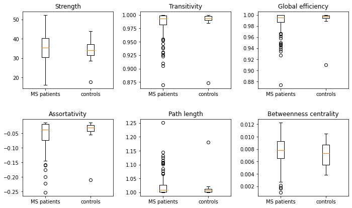

```python
fig, axs = plt.subplots(2, 3,figsize=(10, 6))

plot_metric_boxplot(patients_GM_metrics,controls_GM_metrics,'Strength', [0,0])
plot_metric_boxplot(patients_GM_metrics,controls_GM_metrics,'Transitivity', [0,1])
plot_metric_boxplot(patients_GM_metrics,controls_GM_metrics,'Global efficiency', [0,2])
plot_metric_boxplot(patients_GM_metrics,controls_GM_metrics,'Assortativity', [1,0])
plot_metric_boxplot(patients_GM_metrics,controls_GM_metrics,'Path length', [1,1])
plot_metric_boxplot(patients_GM_metrics,controls_GM_metrics,'Betweenness centrality', [1,2])


fig.subplots_adjust(left=0.08, right=0.98, bottom=0.05, top=0.9,
                    hspace=0.4, wspace=0.3)
```

```python
patients_GM_metrics = drop_outliers(patients_GM_metrics, cmetrics)
controls_GM_metrics = drop_outliers(controls_GM_metrics, cmetrics)
```

```
Old Shape:  (147, 7)
New Shape:  (147, 7)
Old Shape:  (18, 7)
New Shape:  (18, 7)
```

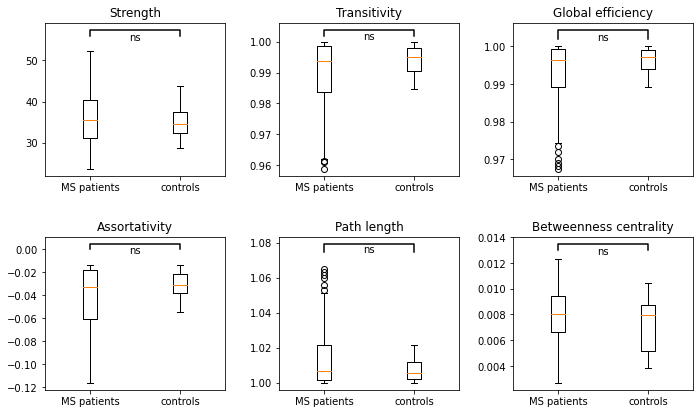

```python
fig, axs = plt.subplots(2, 3,figsize=(10, 6))

plot_metric_boxplot(patients_GM_metrics,controls_GM_metrics,'Strength', [0,0])
y, h, col = 56, 1.5, 'k'
axs[0,0].plot([x1, x1, x2, x2], [y, y+h, y+h, y], lw=1.5, c=col)
axs[0,0].text((x1+x2)*.5, y-h, "ns", ha='center', va='bottom', color=col)

plot_metric_boxplot(patients_GM_metrics,controls_GM_metrics,'Transitivity', [0,1])
y, h, col = 1.002, 0.002, 'k'
axs[0,1].plot([x1, x1, x2, x2], [y, y+h, y+h, y], lw=1.5, c=col)
axs[0,1].text((x1+x2)*.5, y-h, "ns", ha='center', va='bottom', color=col)

plot_metric_boxplot(patients_GM_metrics,controls_GM_metrics,'Global efficiency', [0,2])
y, h, col = 1.002, 0.0025, 'k'
axs[0,2].plot([x1, x1, x2, x2], [y, y+h, y+h, y], lw=1.5, c=col)
axs[0,2].text((x1+x2)*.5, y-h+0.0015, "ns", ha='center', va='bottom', color=col)

plot_metric_boxplot(patients_GM_metrics,controls_GM_metrics,'Assortativity', [1,0])
y, h, col = 0.0, 0.005, 'k'
axs[1,0].plot([x1, x1, x2, x2], [y, y+h, y+h, y], lw=1.5, c=col)
axs[1,0].text((x1+x2)*.5, y-h, "ns", ha='center', va='bottom', color=col)

plot_metric_boxplot(patients_GM_metrics,controls_GM_metrics,'Path length', [1,1])
y, h, col = 1.075, 0.0045, 'k'
axs[1,1].plot([x1, x1, x2, x2], [y, y+h, y+h, y], lw=1.5, c=col)
axs[1,1].text((x1+x2)*.5, y-h+0.003, "ns", ha='center', va='bottom', color=col)

plot_metric_boxplot(patients_GM_metrics,controls_GM_metrics,'Betweenness centrality', [1,2])
y, h, col = 0.0130, 0.0005, 'k'
axs[1,2].plot([x1, x1, x2, x2], [y, y+h, y+h, y], lw=1.5, c=col)
axs[1,2].text((x1+x2)*.5, y-h, "ns", ha='center', va='bottom', color=col)


fig.subplots_adjust(left=0.08, right=0.98, bottom=0.05, top=0.9,
                    hspace=0.4, wspace=0.3)
```

```python
data = global_metrics_summary(patients_GM_metrics,controls_GM_metrics,cmetrics, alternative = 'less')
print(tabulate(data, headers=["Metric", "MS Patients", "Controls", "pvalue"]))
```

```
Metric                  MS Patients    Controls         pvalue
----------------------  -------------  -------------  --------
Strength                (35.98, 6.08)  (35.01, 3.97)  0.733134
Transitivity            (0.99, 0.01)   (0.99, 0.0)    0.193824
Global efficiency       (0.99, 0.01)   (1.0, 0.0)     0.199715
Assortativity           (-0.04, 0.03)  (-0.03, 0.01)  0.173717
Path length             (1.01, 0.02)   (1.01, 0.01)   0.801988
Betweenness centrality  (0.01, 0.0)    (0.01, 0.0)    0.831708
```

```python
bonferroni_correction(data)
print(tabulate(data, headers=["Metric", "MS Patients", "Controls", "pvalue"]))
```

```
Metric                  MS Patients    Controls         pvalue
----------------------  -------------  -------------  --------
Strength                (35.98, 6.08)  (35.01, 3.97)         1
Transitivity            (0.99, 0.01)   (0.99, 0.0)           1
Global efficiency       (0.99, 0.01)   (1.0, 0.0)            1
Assortativity           (-0.04, 0.03)  (-0.03, 0.01)         1
Path length             (1.01, 0.02)   (1.01, 0.01)          1
Betweenness centrality  (0.01, 0.0)    (0.01, 0.0)           1
```

```python
data = global_metrics_summary(patients_GM_metrics,controls_GM_metrics,cmetrics, alternative = 'greater')
print(tabulate(data, headers=["Metric", "MS Patients", "Controls", "pvalue"]))
```

```
Metric                  MS Patients    Controls         pvalue
----------------------  -------------  -------------  --------
Strength                (35.98, 6.08)  (35.01, 3.97)  0.268875
Transitivity            (0.99, 0.01)   (0.99, 0.0)    0.807849
Global efficiency       (0.99, 0.01)   (1.0, 0.0)     0.801988
Assortativity           (-0.04, 0.03)  (-0.03, 0.01)  0.827844
Path length             (1.01, 0.02)   (1.01, 0.01)   0.199715
Betweenness centrality  (0.01, 0.0)    (0.01, 0.0)    0.169831
```

```python
bonferroni_correction(data)
print(tabulate(data, headers=["Metric", "MS Patients", "Controls", "pvalue"]))
```

```
Metric                  MS Patients    Controls         pvalue
----------------------  -------------  -------------  --------
Strength                (35.98, 6.08)  (35.01, 3.97)         1
Transitivity            (0.99, 0.01)   (0.99, 0.0)           1
Global efficiency       (0.99, 0.01)   (1.0, 0.0)            1
Assortativity           (-0.04, 0.03)  (-0.03, 0.01)         1
Path length             (1.01, 0.02)   (1.01, 0.01)          1
Betweenness centrality  (0.01, 0.0)    (0.01, 0.0)           1
```

No se observan diferencias significativas

### 4.2.3. Conectividad funcional

```python
# Listados de matrices de conectividad estructural para cada uno de los grupos
patients_rfMRI = [patients[s]['rfMRI'] for s in patients.keys()]
controls_rfMRI = [controls[s]['rfMRI'] for s in controls.keys()]
```

```python
# Cálculo de métricas de grafos globales
patients_rfMRI_metrics = graph_global_metrics(patients_rfMRI, patients)
controls_rfMRI_metrics = graph_global_metrics(controls_rfMRI, controls)
```

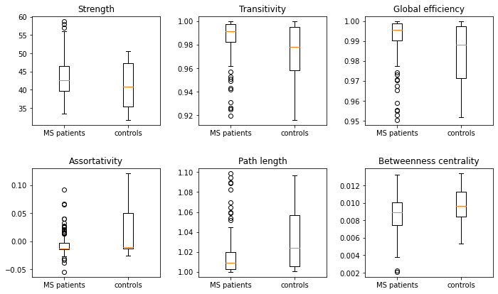

```python
fig, axs = plt.subplots(2, 3,figsize=(10, 6))

plot_metric_boxplot(patients_rfMRI_metrics,controls_rfMRI_metrics,'Strength', [0,0])
plot_metric_boxplot(patients_rfMRI_metrics,controls_rfMRI_metrics,'Transitivity', [0,1])
plot_metric_boxplot(patients_rfMRI_metrics,controls_rfMRI_metrics,'Global efficiency', [0,2])
plot_metric_boxplot(patients_rfMRI_metrics,controls_rfMRI_metrics,'Assortativity', [1,0])
plot_metric_boxplot(patients_rfMRI_metrics,controls_rfMRI_metrics,'Path length', [1,1])
plot_metric_boxplot(patients_rfMRI_metrics,controls_rfMRI_metrics,'Betweenness centrality', [1,2])


fig.subplots_adjust(left=0.08, right=0.98, bottom=0.05, top=0.9,
                    hspace=0.4, wspace=0.3)
```

```python
patients_rfMRI_metrics = drop_outliers(patients_rfMRI_metrics, cmetrics)
controls_rfMRI_metrics = drop_outliers(controls_rfMRI_metrics, cmetrics)
```

```
Old Shape:  (147, 7)
New Shape:  (147, 7)
Old Shape:  (18, 7)
New Shape:  (18, 7)
```

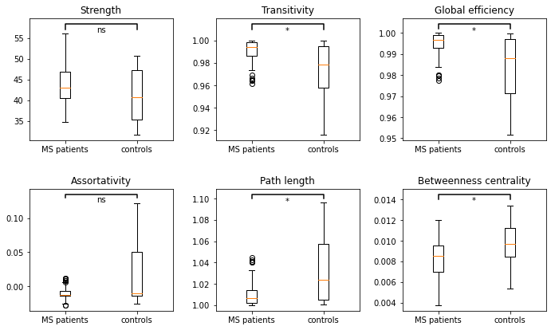

```python
fig, axs = plt.subplots(2, 3,figsize=(10, 6))

plot_metric_boxplot(patients_rfMRI_metrics,controls_rfMRI_metrics,'Strength', [0,0])
y, h, col = 57, 1.5, 'k'
axs[0,0].plot([x1, x1, x2, x2], [y, y+h, y+h, y], lw=1.5, c=col)
axs[0,0].text((x1+x2)*.5, y-h+0.5, "ns", ha='center', va='bottom', color=col)

plot_metric_boxplot(patients_rfMRI_metrics,controls_rfMRI_metrics,'Transitivity', [0,1])
y, h, col = 1.01, 0.005, 'k'
axs[0,1].plot([x1, x1, x2, x2], [y, y+h, y+h, y], lw=1.5, c=col)
axs[0,1].text((x1+x2)*.5, y-h+0.0005, "*", ha='center', va='bottom', color=col)

plot_metric_boxplot(patients_rfMRI_metrics,controls_rfMRI_metrics,'Global efficiency', [0,2])
y, h, col = 1.002, 0.0025, 'k'
axs[0,2].plot([x1, x1, x2, x2], [y, y+h, y+h, y], lw=1.5, c=col)
axs[0,2].text((x1+x2)*.5, y-h-0.0003, "*", ha='center', va='bottom', color=col)

plot_metric_boxplot(patients_rfMRI_metrics,controls_rfMRI_metrics,'Assortativity', [1,0])
y, h, col = 0.13, 0.005, 'k'
axs[1,0].plot([x1, x1, x2, x2], [y, y+h, y+h, y], lw=1.5, c=col)
axs[1,0].text((x1+x2)*.5, y-h-0.004, "ns", ha='center', va='bottom', color=col)

plot_metric_boxplot(patients_rfMRI_metrics,controls_rfMRI_metrics,'Path length', [1,1])
y, h, col = 1.10, 0.004, 'k'
axs[1,1].plot([x1, x1, x2, x2], [y, y+h, y+h, y], lw=1.5, c=col)
axs[1,1].text((x1+x2)*.5, y-h-0.002, "*", ha='center', va='bottom', color=col)

plot_metric_boxplot(patients_rfMRI_metrics,controls_rfMRI_metrics,'Betweenness centrality', [1,2])
y, h, col = 0.0140, 0.0005, 'k'
axs[1,2].plot([x1, x1, x2, x2], [y, y+h, y+h, y], lw=1.5, c=col)
axs[1,2].text((x1+x2)*.5, y-h, "*", ha='center', va='bottom', color=col)


fig.subplots_adjust(left=0.08, right=0.98, bottom=0.05, top=0.9,
                    hspace=0.4, wspace=0.3)
```

```python
data = global_metrics_summary(patients_rfMRI_metrics,controls_rfMRI_metrics,cmetrics,alternative='less')
print(tabulate(data, headers=["Metric", "MS Patients", "Controls", "pvalue"]))
```

```
Metric                  MS Patients    Controls           pvalue
----------------------  -------------  -------------  ----------
Strength                (43.88, 4.52)  (40.69, 6.49)  0.976456
Transitivity            (0.99, 0.01)   (0.97, 0.03)   0.998619
Global efficiency       (1.0, 0.01)    (0.98, 0.02)   0.998622
Assortativity           (-0.01, 0.01)  (0.01, 0.04)   0.062536
Path length             (1.01, 0.01)   (1.03, 0.03)   0.00140691
Betweenness centrality  (0.01, 0.0)    (0.01, 0.0)    0.00346001
```

```python
bonferroni_correction(data)
print(tabulate(data, headers=["Metric", "MS Patients", "Controls", "pvalue"]))
```

```
Metric                  MS Patients    Controls       pvalue
----------------------  -------------  -------------  ------------------------
Strength                (43.88, 4.52)  (40.69, 6.49)  1.0
Transitivity            (0.99, 0.01)   (0.97, 0.03)   1.0
Global efficiency       (1.0, 0.01)    (0.98, 0.02)   1.0
Assortativity           (-0.01, 0.01)  (0.01, 0.04)   0.37521625853066054
Path length             (1.01, 0.01)   (1.03, 0.03)   0.008441475482890511 (*)
Betweenness centrality  (0.01, 0.0)    (0.01, 0.0)    0.020760070710555658 (*)
```

```python
data = global_metrics_summary(patients_rfMRI_metrics,controls_rfMRI_metrics,cmetrics,alternative='greater')
print(tabulate(data, headers=["Metric", "MS Patients", "Controls", "pvalue"]))
```

```
Metric                  MS Patients    Controls           pvalue
----------------------  -------------  -------------  ----------
Strength                (43.88, 4.52)  (40.69, 6.49)  0.0238949
Transitivity            (0.99, 0.01)   (0.97, 0.03)   0.00140962
Global efficiency       (1.0, 0.01)    (0.98, 0.02)   0.00140691
Assortativity           (-0.01, 0.01)  (0.01, 0.04)   0.938232
Path length             (1.01, 0.01)   (1.03, 0.03)   0.998622
Betweenness centrality  (0.01, 0.0)    (0.01, 0.0)    0.996605
```

```python
bonferroni_correction(data)
print(tabulate(data, headers=["Metric", "MS Patients", "Controls", "pvalue"]))
```

```
Metric                  MS Patients    Controls       pvalue
----------------------  -------------  -------------  ------------------------
Strength                (43.88, 4.52)  (40.69, 6.49)  0.14336917161866267
Transitivity            (0.99, 0.01)   (0.97, 0.03)   0.008457718766114102 (*)
Global efficiency       (1.0, 0.01)    (0.98, 0.02)   0.008441475482890511 (*)
Assortativity           (-0.01, 0.01)  (0.01, 0.04)   1.0
Path length             (1.01, 0.01)   (1.03, 0.03)   1.0
Betweenness centrality  (0.01, 0.0)    (0.01, 0.0)    1.0
```

### 4.2.4. Multilayer

```python
def calc_pca(data, metric):
    x = data[[metric+'_FA',metric+'_GM',metric]]
    x_scaled = StandardScaler().fit_transform(x)
    pca = PCA(n_components=1)
    pca_features = pca.fit_transform(x_scaled)

    pca_df = pd.DataFrame(
    data=pca_features,
    columns=[metric+'_all'])
    data = pd.concat([data,pca_df], axis = 1)
    return data
```

```python
patients_metrics = pd.merge(pd.merge(patients_FA_metrics,patients_GM_metrics,how = 'inner',
                                     on='subjects',suffixes=['_FA','_GM'])
                            ,patients_rfMRI_metrics,how = 'inner', on='subjects',suffixes=['_a ','_rfMRI'])

controls_metrics = pd.merge(pd.merge(controls_FA_metrics,controls_GM_metrics,how = 'inner',
                                     on='subjects',suffixes=['_FA','_GM'])
                            ,controls_rfMRI_metrics,how = 'inner', on='subjects',suffixes=['_a ','_rfMRI'])
```

```python
for metric in cmetrics:
    patients_metrics = calc_pca(patients_metrics, metric)
    controls_metrics = calc_pca(controls_metrics, metric)
    #
    patients_metrics[metric+'_all2'] = (patients_metrics[metric]+patients_metrics[metric+'_FA']+patients_metrics[metric+'_GM'])/3
    #

patients_metrics = patients_metrics[['subjects', 'Strength_all', 'Transitivity_all',
                                     'Global efficiency_all' ,'Assortativity_all',
                                     'Path length_all', 'Betweenness centrality_all']]

controls_metrics = controls_metrics[['subjects', 'Strength_all', 'Transitivity_all',
                                     'Global efficiency_all' ,'Assortativity_all',
                                     'Path length_all', 'Betweenness centrality_all']]
```

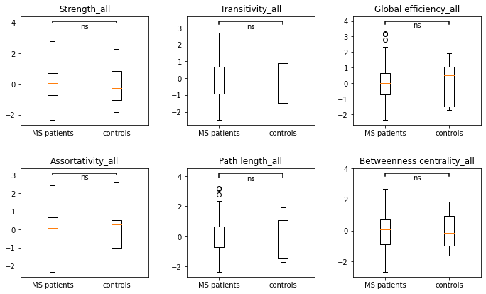

```python
fig, axs = plt.subplots(2, 3,figsize=(10, 6))

plot_metric_boxplot(patients_metrics,controls_metrics,'Strength_all', [0,0])
y, h, col = 4, 0.1, 'k'
axs[0,0].plot([x1, x1, x2, x2], [y, y+h, y+h, y], lw=1.5, c=col)
axs[0,0].text((x1+x2)*.5, y-h-0.4, "ns", ha='center', va='bottom', color=col)

plot_metric_boxplot(patients_metrics,controls_metrics,'Transitivity_all', [0,1])
y, h, col = 3.2, 0.2, 'k'
axs[0,1].plot([x1, x1, x2, x2], [y, y+h, y+h, y], lw=1.5, c=col)
axs[0,1].text((x1+x2)*.5, y-h-0.15, "ns", ha='center', va='bottom', color=col)

plot_metric_boxplot(patients_metrics,controls_metrics,'Global efficiency_all', [0,2])
y, h, col = 3.8, 0.2, 'k'
axs[0,2].plot([x1, x1, x2, x2], [y, y+h, y+h, y], lw=1.5, c=col)
axs[0,2].text((x1+x2)*.5, y-h-0.1, "ns", ha='center', va='bottom', color=col)

plot_metric_boxplot(patients_metrics,controls_metrics,'Assortativity_all', [1,0])
y, h, col = 3, 0.1, 'k'
axs[1,0].plot([x1, x1, x2, x2], [y, y+h, y+h, y], lw=1.5, c=col)
axs[1,0].text((x1+x2)*.5, y-h-0.2, "ns", ha='center', va='bottom', color=col)

plot_metric_boxplot(patients_metrics,controls_metrics,'Path length_all', [1,1])
y, h, col = 3.9, 0.3, 'k'
axs[1,1].plot([x1, x1, x2, x2], [y, y+h, y+h, y], lw=1.5, c=col)
axs[1,1].text((x1+x2)*.5, y-h-0.002, "ns", ha='center', va='bottom', color=col)

plot_metric_boxplot(patients_metrics,controls_metrics,'Betweenness centrality_all', [1,2])
y, h, col = 3.5, 0.2, 'k'
axs[1,2].plot([x1, x1, x2, x2], [y, y+h, y+h, y], lw=1.5, c=col)
axs[1,2].text((x1+x2)*.5, y-h-0.15, "ns", ha='center', va='bottom', color=col)


fig.subplots_adjust(left=0.08, right=0.98, bottom=0.05, top=0.9,
                    hspace=0.4, wspace=0.3)
```

[output not shown]

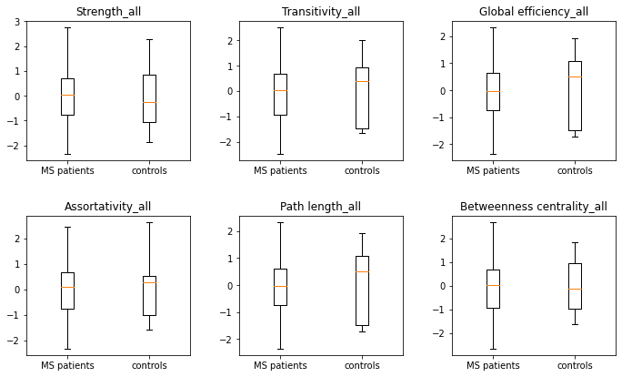

```python
cmetrics2 = ['Strength_all', 'Transitivity_all',  'Global efficiency_all' ,'Assortativity_all',
             'Path length_all', 'Betweenness centrality_all']

patients_metrics = drop_outliers(patients_metrics, cmetrics2)
controls_metrics = drop_outliers(controls_metrics, cmetrics2)

fig, axs = plt.subplots(2, 3,figsize=(10, 6))

plot_metric_boxplot(patients_metrics,controls_metrics,'Strength_all', [0,0])
plot_metric_boxplot(patients_metrics,controls_metrics,'Transitivity_all', [0,1])
plot_metric_boxplot(patients_metrics,controls_metrics,'Global efficiency_all', [0,2])
plot_metric_boxplot(patients_metrics,controls_metrics,'Assortativity_all', [1,0])
plot_metric_boxplot(patients_metrics,controls_metrics,'Path length_all', [1,1])
plot_metric_boxplot(patients_metrics,controls_metrics,'Betweenness centrality_all', [1,2])


fig.subplots_adjust(left=0.08, right=0.98, bottom=0.05, top=0.9,
                    hspace=0.4, wspace=0.3)
```

```python
data = global_metrics_summary(patients_metrics,controls_metrics,cmetrics2,alternative='less')
print(tabulate(data, headers=["Metric", "MS Patients", "Controls", "pvalue"]))
```

```
Metric                      MS Patients    Controls        pvalue
--------------------------  -------------  ------------  --------
Strength_all                (-0.0, 1.15)   (-0.0, 1.27)  0.573157
Transitivity_all            (-0.08, 1.03)  (0.0, 1.31)   0.391034
Global efficiency_all       (-0.09, 1.02)  (0.0, 1.3)    0.343708
Assortativity_all           (0.04, 0.99)   (0.0, 1.08)   0.615388
Path length_all             (-0.09, 1.02)  (-0.0, 1.3)   0.340629
Betweenness centrality_all  (-0.03, 1.07)  (0.0, 1.14)   0.530069
```

```python
bonferroni_correction(data)
print(tabulate(data, headers=["Metric", "MS Patients", "Controls", "pvalue"]))
```

```
Metric                      MS Patients    Controls        pvalue
--------------------------  -------------  ------------  --------
Strength_all                (-0.0, 1.15)   (-0.0, 1.27)         1
Transitivity_all            (-0.08, 1.03)  (0.0, 1.31)          1
Global efficiency_all       (-0.09, 1.02)  (0.0, 1.3)           1
Assortativity_all           (0.04, 0.99)   (0.0, 1.08)          1
Path length_all             (-0.09, 1.02)  (-0.0, 1.3)          1
Betweenness centrality_all  (-0.03, 1.07)  (0.0, 1.14)          1
```

```python
data = global_metrics_summary(patients_metrics,controls_metrics,cmetrics2,alternative='greater')
print(tabulate(data, headers=["Metric", "MS Patients", "Controls", "pvalue"]))
```

```
Metric                      MS Patients    Controls        pvalue
--------------------------  -------------  ------------  --------
Strength_all                (-0.0, 1.15)   (-0.0, 1.27)  0.430133
Transitivity_all            (-0.08, 1.03)  (0.0, 1.31)   0.612181
Global efficiency_all       (-0.09, 1.02)  (0.0, 1.3)    0.659371
Assortativity_all           (0.04, 0.99)   (0.0, 1.08)   0.387819
Path length_all             (-0.09, 1.02)  (-0.0, 1.3)   0.662439
Betweenness centrality_all  (-0.03, 1.07)  (0.0, 1.14)   0.473267
```

```python
bonferroni_correction(data)
print(tabulate(data, headers=["Metric", "MS Patients", "Controls", "pvalue"]))
```

```
Metric                      MS Patients    Controls        pvalue
--------------------------  -------------  ------------  --------
Strength_all                (-0.0, 1.15)   (-0.0, 1.27)         1
Transitivity_all            (-0.08, 1.03)  (0.0, 1.31)          1
Global efficiency_all       (-0.09, 1.02)  (0.0, 1.3)           1
Assortativity_all           (0.04, 0.99)   (0.0, 1.08)          1
Path length_all             (-0.09, 1.02)  (-0.0, 1.3)          1
Betweenness centrality_all  (-0.03, 1.07)  (0.0, 1.14)          1
```